# Task_Copula

Внимание!!! Параметры копулы передаются в следующую функцию через параметр `theta`. При программировании не забудьте, что для всех копул, кроме копулы Стьюдента это скаляр- по смыслу коэффициент корреляции , а для копулы Стьюдента, это вектор длины два, например такой

-0.7532619 5.9154939

Первое число это собственно коэффициент корреляции, второе число это число степеней свободы (оно может быть не целым) в распределении Стьюдента.

```r
quantileLevel <- function(numCopula,copula, theta,alpha)
{
  if (numCopula == 1)
  {
#Gaussian
    q <- pnorm(qnorm(alpha) *sqrt(1-theta*theta)  + theta* qnorm(copula[,1]))
  }
  if (numCopula == 2)
  {

      #Student
  }
  if (numCopula == 3)
  {
    #Frank
  }
  if (numCopula == 4)
  {
    #Clayton
  }
  return(q)
}
copula <- cbind(predictor.copula,output.copula)
alpha <- 0.95
copulanum <- 1
parameters <- normal_copula.fit@copula@parameters
quantile <- quantileLevel(copulanum,copula, parameters,alpha)
```

10.Определите аномальные пары переменных

$$(predictor.copula_1,.output.copula_1),...,(predictor.copula_k,output.copula_k)$$

для которых переменная output в копуле превосходит квантиль. Определяем индексы таких переменных.

```r
(anomalindex <- which(copula[,2]>quantile))
```

```
##  [1]  19  88 125 134 164 186 204 242 275 291 292 296 310 312 315 333 377 378 383
## [20] 398 413 456 474 482
```

Рисуем копулу, цветом выделяем аномальные значения

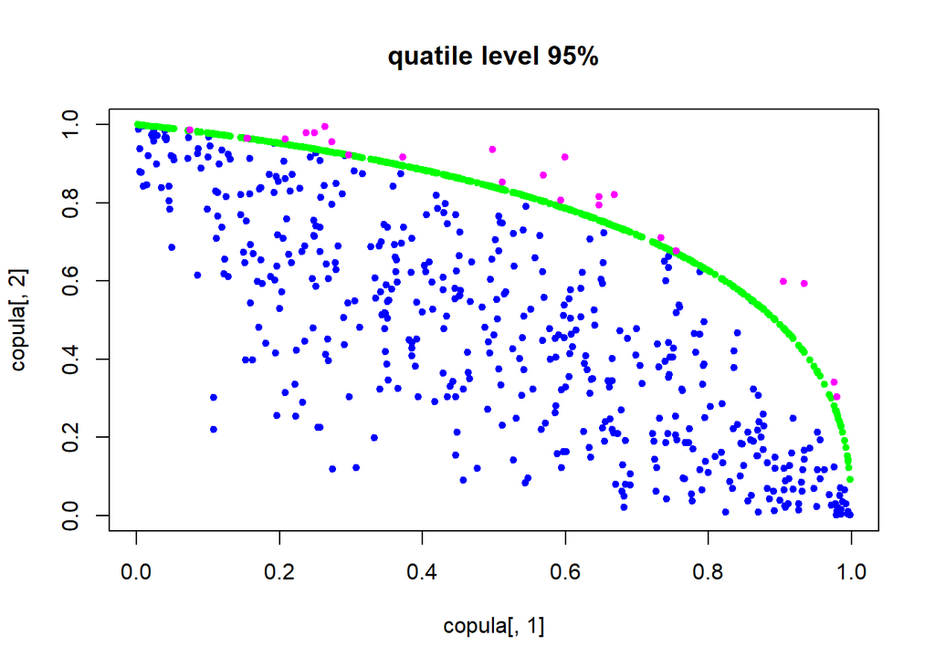

```r
plot(copula[,1],copula[,2],pch =20,col = "blue",main = "quatile level 95%")
points(copula[,1],quantile,col = "green",pch = 20)
points(copula[anomalindex,1],copula[anomalindex,2],col = "magenta",pch = 20)
```

11.Находим аномальные переменные в исходных pedictor и output.
$$(predictor_1,output_1),...,(predictor_k,output_k)$$
Создадим для их хранения переменные anomal_predictor и anomal_output

```r
anomal_predictor <- data$predictor[anomalindex]
anomal_output    <- data$output[anomalindex]
head(anomal_predictor)
```

```
## [1]  4.931877  2.132965  1.522476  2.135027 -3.314548  7.152332
```

```r
head(anomal_output)
```

```
## [1] 0.4564973 0.8458270 1.0236919 0.7877090 2.1567574 0.1804066
```

Выделим цветом пары аномальных переменных

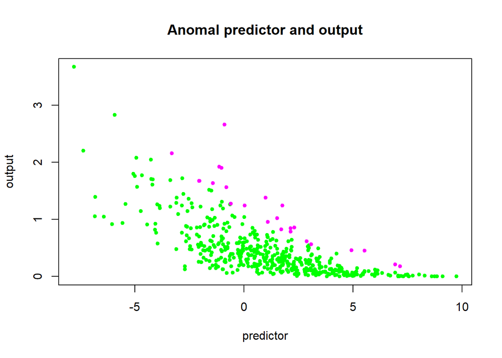

Создайте переменную variant и положите ее равной номеру Вашего варианта, например, вариант номер 0

```r
  variant <- 0
```

Создайте переменную copulaName и положите ее равной названию копулы, которую Вы выбрали, например выбрана копула номер 1.

```r
copulaNames <- c("normal", "student", "clayton","frank")
copulaName <-copulaNames[copulanum]
copulaName
```

```
## [1] "normal"
```

Создайте переменную myResult типа list следующего вида. И сохраните ее в файл result.rds.

Имена переменных в левой части оператора `=` листа обязательны именно такие.

```r
myResult <- list(variant = variant,
                 copulaName = copulaName,
                 predictor.copula = predictor.copula,
                 output.copula = output.copula,
                 best_parameters = best_parameters,
                 anomal_predictor= anomal_predictor,
                 anomal_output= anomal_output)

saveRDS(myResult,"result.rds")
```

Запустите шайни для проверки результата. Нажмите кнопку `Browse` и загрузите свой файл с решением result.rds и смотрите на результат. Шайни для проверки Теста 5 находится на сервере по адресу https://shiny.ilykei.com/ANDoynikov/Copula_test/